# MIDI-MT - Модуль управления устройствами «Умного Дома»

MIDI-MT Документация на Русском языке

## Управление устройствами умного дома

- Поддержка протокола обмена MQTT
- Настройки модуля управления устройствами «Умного Дома»
- Настройка MQTT соединения
  - SSL/TLS - настройка сертификата
  - PSK - настройка ключей
- Настройки MQTT сервера
  - Структура MQTT тем - топиков
- Настройки привязок органов управления
- Конфигурационный файл
- Лог файл

```
    MQTT - Message Queuing Telemetry Transport
```

Вы можете интегрировать **MIDI клавиатуру** в систему своего умного дома, для управления различными устройствами.  
Поддерживаются любые среды управления **Умным Домом**, которые базируются на протоколе обмена MQTT и имеют в своем составе MQTT сервер. В системе Умного Дома протокол MQTT должен быть не ниже уровня `5.0`, возможна работа и с более ранними версиями, но стабильность и полная работоспособность для всех команд не гарантируется.

Рекомендуем следующие совместимые решения для управления Умным Домом:

- любая система работающая на основе MQTT брокера `mosquitto`,
- [`Home Assistant`](https://www.home-assistant.io/),
- [`openHAB`](https://www.openhab.org/),
- [`MajorDoMo`](https://mjdm.ru/),
- [`ioBroker`](https://www.iobroker.net/),
- [`Domoticz`](https://www.domoticz.com/),
- [`MyController`](https://www.mycontroller.org/),
- [`IntraHouse`](https://intrahouse.ru/ih-smart-home/),
- и так далее..

### Настройки модуля управления устройствами «Умного Дома»

- В поле «**MQTT сервер**» необходимо указать IP адрес MQTT сервера.
- Поле «**Порт**» указывает по какому порту отправлять запросы MQTT серверу, , по умолчанию номер порта `1883`.
- Поле «**Логин**» должно соответствовать учётной записи на MQTT сервере.
- Поле «**Пароль**» также должно соответствовать учётной записи на MQTT сервере.
- «**Ключ PSK**» - другая форма авторизации, вместо пары логин/пароль. Используется что то одно.
- Опця «**SSL/TLS включено**» позволяет устанавливать защищённое соединение, если MQTT сервер это поддерживает.
- Опция «**Само-подписанный сертификат**» позволяет устанавливать соединение с сервером на ккотором установлен само-подписанный сертификат.
- Поле «**CA сертификат**» указывает на путь к файлу корневого сертификата MQTT сервера, если вам такой выдали.
- Поле «**MQTT топик префикс**» указывает на необязательный префикс к «**MQTT топикам**».
- Выбор «**Уровень логирования MQTT сессий**» включает или выключает запись отладочной информации о сетевом обмене и командах в общий лог файл.

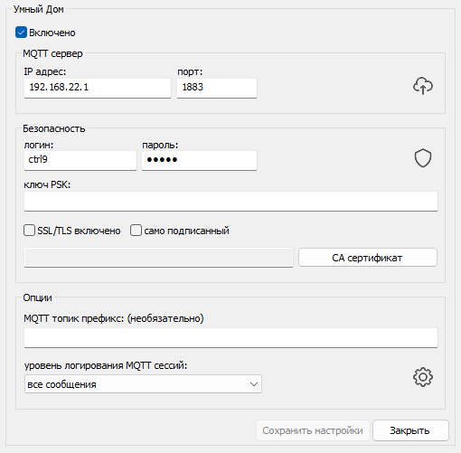

##### **Настройка MQTT соединения**

###### SSL/TLS - настройка сертификата

Файл сертификата, путь к кторому вы должны указать в конфигурации, должен состоять как минимум из сертификата `CA` (Certificate Authority), который подписал сертификат вашего сервера MQTT. Если у вас есть цепочка из необходимых сертификатов, то необходимо разместить корневой сертификат в отдельной папке, в неё же добавить остальные необходимые сертификаты. Например корневой сертификат компании `Let's Encrypt` имеет название `R3`. Если вы используете сертификат от этой компании, то вам достаточно указать путь к файлу `R3.cert` или `R3.pem` в формате `PEM`.

В случае само-подписанного сертификата, вполне достаточно указать его, при этом установив галочку над одноименным пунктом. В этом случае сертификат MQTT сервера будет таким же, как и сертификат CA.

Для активации SSL/TLS установите галочку над соответствующим пунктом. Используйте эти параметры, только если хотите зашифровать связь между клиентом и сервером. В локальной сети, это как правило делать не стоит. Так как это повышает нагрузку как на клиента, так и на сервер.

###### PSK - настройка ключей

Работа с PSK ключами не совсестима с SSL/TLS настройками. Соединение может работать только в одном из указанных режимов, при заполнении всех значений, приоритет отдается соединению на основе PSK ключей. Используют PSK ключи, как правило, при работе с внешними серверами, настрока авторизации которых происходит через их же Вэб интерфейс. Например [`AdaFruit MQTT`](https://io.adafruit.com/api/docs/#about-the-api-docs) или [`HiveMQ Public MQTT Broker`](https://www.hivemq.com/public-mqtt-broker/).

Вся настройка сводиться к получению ключа, и копированием его в соответствующее поле. Вторым параметром связки PSK ключа, является ваш логин на MQTT сервер, так как вы его уже заполнили выше, то это все настройки которые можно применить.

### Настройки MQTT сервера

##### **MQTT темы (топики)**

MIDI-MT использует следующую структуру MQTT топиков:

```
    /sensor/<логин для MQTT сервера>/<идентификатор контрола>/<имя значения>
```

Пример используемых топиков. Предположим что ваш логин для сервера MQTT - `ectrl9`, идентификатор контрола плавно регулирующего освещение имеет название `av1` и контрол включающий или выключающий свет имеет идентификатор `b11`. В таком случае, упавляющие команды будут отправлены в следующие топики:

```
    /sensor/ectrl9/av1/level = от 0 до 127
    /sensor/ectrl9/b11/onoff = 1 или 0
```

Имя контрола задаётся автоматически, в соответствии с выбранным в редакторе идентификатором контрола. Его можно получить, обратившись к топику:

```
    /sensor/ectrl9/av1/title = "уровень 1"
    /sensor/ectrl9/b11/title = "вкл/выкл 1"
```

Для некоторых сценариев, будет полезна информация о статусе подключении MIDI клавиатуры. Проверить её текущее состояние можно обратившись к топику:

```
    /sensor/ectrl9/state = 1 или 0
```

Если вы плохо ориентируетесь в протоколе MQTT, или в устройстве Умного Дома, в этом случае, рекомендуем прочесть книгу:

- [MQTT Essentials E-Book](https://www.hivemq.com/download-mqtt-ebook/),  
  или есть он-лайн вариант:
- [MQTT Essentials](https://www.hivemq.com/mqtt-essentials/) и [MQTT версия 5 Essentials](https://www.hivemq.com/mqtt-5/).

### Настройки привязок органов управления

Необходимые контролы можно настроить в редакторе конфигураций. Настройки MQTT соединения сохраняются в файле конфигурации, по этому возможно иметь неограниченное число настроенных конфигураций, которые можно загружать по мере необходимости.

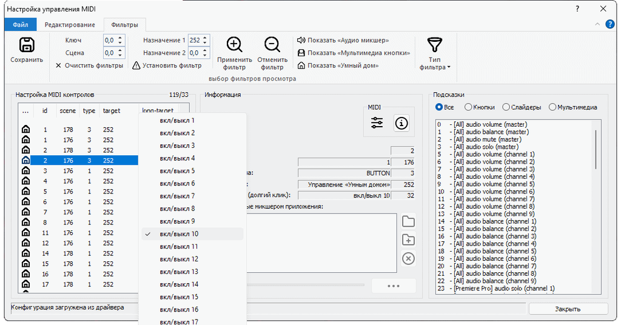

#### Конфигурационный файл

Настройки в конфигурационном файле, выглядят следующим образом:

```yaml
{
    ...
    "mqtt": {
        "enable": true,            // блок настроек 'Умного Дома',
        "host": "192.168.22.1",    // учётная запись клиента
        "login": "ctrl9",          // на MQTT сервере
        "pass": "12345",
        "prefix": "",
        "sslpsk": "",
        "certcapath": "",
        "port": 1883,
        "loglevel": 16,
        "isssl": false,
        "selfsigned": false
    },
    ...
}
```

#### Лог файл

Из практических рекомендаций: уровень логирования, может помочь в отладке, связанной с первым подключением к серверу. В дальнейшем, его лучше выключить, так как это создаёт дополнительную нагрузку для сервера, так как он транслирует всю информацию о собственных действиях. К локальным сообщениям, уровень лога отношение не имеет.

###### Пример лог файла

```
[07-25 -> 16:58:38] Common::MQTT::on_log: Client ctrl9-4687392 sending CONNECT
[07-25 -> 16:58:38] Common::MQTT::on_log: Client ctrl9-4687392 sending PUBLISH (d0, q0, r1, m1, 'sensor/ctrl9/state', ... (1 bytes))
[07-25 -> 16:58:38] Common::MQTT::SmartHome::Start: The Smart-Home control service is running.
[07-25 -> 16:58:38] Common::MQTT::on_log: Client ctrl9-4687392 sending PUBLISH (d0, q0, r1, m2, 'sensor/ctrl9/b37/title', ... (9 bytes))
...
```